# Table Exploration

## Preliminaries

Here is the code to set up our table to get started. I added a new line at top that tells the notebook to show what we plot in the notebook.

```
%matplotlib inline
```

More on plotting later. For now know that you have to put this line as first piece of code in your notebook to see your plots.

**Important note:** this line of code is not Python but instead instructions to the notebook. If you try to include it in a Poco assessment, you will get an error.

```python
%matplotlib inline

from csv import DictReader

from urllib2 import urlopen

url = 'https://docs.google.com/spreadsheets/d/1z1ycUZjJpmMWB4gXbhwRQ9B_qa42CwzAQkf82mLibxI/pub?output=csv'

response = urlopen(url)

titanic_table = [row for row in DictReader(response)]

print(titanic_table[0])  # print the first row of the table - Mr. Braund

print(len(titanic_table))
```

```
{'Fare': '7.25', 'Name': 'Braund, Mr. Owen Harris', 'Embarked': 'S', 'Age': '22', 'Parch': '0', 'Pclass': '3', 'Sex': 'male', 'Survived': '0', 'SibSp': '1', 'PassengerId': '1', 'Ticket': 'A/5 21171', 'Cabin': ''}
891
```

## What are we doing

At this point let's revisit the overall survival rate. In previous modules we found that 38% of passengers survived (and 62% perished). I'd now like to see if we can tease this apart a bit. Can I characterize those who survived (or those who perished)? Were most of the passengers who survived of a specific gender? Were most of the passengers who survived in a specific class? Were most of those who survived in a specific age group?

If you were writing a history paper or a social science paper, this type of information could be of interest by itself. Perhaps you can link social norms of the Titanic era to those who survived. It could add a further argument to a thesis you come up with, e.g., "women and children first" was only a slogan and not actually enacted when a catastrophe occured. You bolster your thesis by showing results from the Titanic.

In this course we have a slightly different focus. We want to use information about a passenger to predict whether they survived or not. So we want to find columns that correlate well with values in the `Survived` column. Can values in a column be shown to helpfully predict survival? Or vice versa, can values in a column be shown to helpfully predict perishing?

What do I mean by "helpfully"? We need predictions that are better than our 38/62 default. If I coded a predictor that ignored all other data about a passenger and just predicted "perished", I would be right 62% of the time (we will do exactly this in a subsequent module). We are searching for columns that will allow us to improve on this. Can I write a predictor that will get me to 80% accuracy? How about 90%? 100%?

In this module we will start to look at different columns and do some counting. We want to be able to anwser quesitons like *How many people were there in 3rd class?* Or *How many people embarked from Cherbourg?* We will also want to start looking at correlation with the Survived column. *How many people survived in 3rd class?* We will take what we learn and start to build a predictor in later modules.

## Let's focus on female passengers to start

First I'll build a sub-table of female passengers. I'll count how many there were.

```python
female_table = [row for row in titanic_table if row['Sex'] == 'female']
len(female_table)  # 314 female passengers
```

```
314
```

## Female survivors

My next question is how many females survived. In the last module, I did a map to get the Survived column then a reduce using sum to get the count. I'll do that again for practice here but then look at a different way of getting similar results.

One caveat: I am going to combine two map operations into one. In the prior module I used a map to pull out a column and then another map to produce a numeric value from a string. My one map below does both: it pulls out the Survived value and then converts it to an int and then copies it to the new list. If you feel more comfortable doing it as 2 separate maps, no problem.

And note that we are working with the sub-table `female_table`, not the larger `titanic_table`. What does this mean? We are asking out of all the females (total of 314 as we printed above), how many survived?

```python
female_survival = [int(row['Survived']) for row in female_table]

female_survivor_count = sum(female_survival)
female_survival_percentage = float(female_survivor_count)/len(female_table)
print(female_survival_percentage)  # .74 - wow
```

```
0.742038216561
```

So female passengers had almost twice the survival rate as all passengers taken together. I'll make a mental note to remember that the Sex column is "helpful". It would appear to allow us to improve on the simple everyone-perished predictor's accuarcy of 62%, at least when looking at female passengers. Predicting *survived* on the `female_table` would give me a 74% accuracy rate. That's good but remember that males outnumbered females almost 2 to 1, so we still have more exploration to do.

## A shortcut

I'll continue to use the two lines below as a model in this module. First I generate a sub-table and then pull a column from it while changing each value to an int:

```
female_table = [row for row in titanic_table if row['Sex'] == 'female']
female_survival = [int(row['Survived']) for row in female_table]
```

However, there is a short-cut that combines both of these lines into a single line by removing the need to create the sub-table:

```python
female_survival = [int(row['Survived']) for row in titanic_table if row['Sex'] == 'female']
```

Feel free to use this more compact version if you wish. It combines filtering with mapping to ints in one statement.

## Getting ready for plotting

We could continue to compute percentages and print them out. But sometimes it is more powerful to visualize data in a plot or graph. We are going to need to add a package to Python to do visualization. The package is called `matplotlib`. The *lib* is pronounced as in *bib*. Here is the line of code I will use to pull the package in so I can use it.

```
import matplotlib.pyplot as plt
```

You will notice that I actually import from `matplotlib.pyplot`. Python allows me to choose sub-packages using the dot notation. In essence we are saying look in the (big!) matplotlib package for the sub-package called pyplot - that is the one I want.

The import statement looks a bit odd. We have seen `from math import sqrt`. I could do something similar here, i.e., import only the functions I will be using. However, it is such standard practice in the python community to use the `import as` format for `matplotlib` that I feel loathe to break it.

So what does `import as` do. It imports *all* functions in the pyplot sub-package. Similarly, if I did `import math` I would get all math functions imported. The downside of using import this way is that you have to prefix each function you use with the full package name. I'll give you a couple examples below using math.

```python
from math import sqrt  # what we have seen up until now

print(sqrt(2.7))  # no prefix needed
```

```
1.64316767252
```

```python
import math  # pulls in all functions but have to prefix

print( math.sqrt(2.7))  # notice I now need prefix
```

```
1.64316767252
```

```python
import math as my_math  # new - gives nickname to package

print( my_math.sqrt(2.7))  # still have to use nickname
```

```
1.64316767252
```

Getting back to matplotlib, if I wanted to use a function called `hist` from the package, I would need to write `matplotlib.pyplot.hist()`. Yuck. To make it more palatable, I can give a nickname to that full path, in this case `plt`. As you will see, I still need to prefix functions from the package but now get to use `plt.hist()`. A little better. BTW: the use of `plt` is also standard. You could choose your own variable nickname but stick with `plt` to make your life easier.

## Plotting female survivors

The plotting functions we will use all take one or more lists of values as arguments then plot those values and give us a visualization. We will use our normal way of producing those lists by mapping columns from a table. And we already have a list of survival values in `female_survival`. Let's try using a histogram (using `plt.hist`) to see what things look like. We will supply the `hist` function with two things:

1. a list of numbers - cannot be strings. In our case the variable `female_survival` contains this list.
2. an integer that says how many bins to use. In our case, 2.

Why 2 bins? Because I want a bin for 0 values and a bin for 1 values.

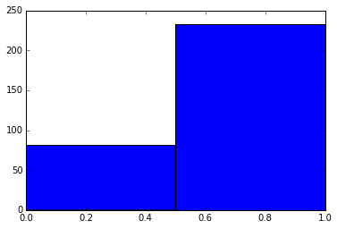

```python
import matplotlib.pyplot as plt

plt.hist(female_survival, 2)  #list of values, number of bins to use

plt.show()
```

Kind of rough around the edges but not bad. The `hist` function divides the x axis into the bins and then shows with a bar how many values fall in each bin. The bar on the left shows the count of 0 values, the one on the right the count of 1 values.

## Let's clean up the plot

The problem with the plot above is that I don't know what the visualization means without looking at the code that produced it. What if I wanted to use the plot in a paper or blog entry I am writing? BTW: you can grab the plot as a image file and download it to your computer. Right-click on it. Once on your computer, you can insert it into something you are writing to make a point or bolster your argument.

Let's add some more information to the plot. I'd like to label each axis and also the plot as a whole. The ticks on the x axis are also odd, being in decimal places. I'll add some code to do clean-up.

Before I get to the code, you need some background on how plotting works. Up until now we have been assigning values to variables. As you can see below, there are no assignment statements; you won't see an `=`. What is happening is that the `plt` package is working in the background to get our plot ready for us. We give it instructions by calling functions. Kind of like the stage-crew sets up the stage for the actual performance. When we are ready, we tell plt to go ahead and `show` us what we have put together. Again, it is a type of pipeline or workflow that is typical of many Python packages. Get everything set up then as the final step do the actual work.

I am putting a label on the x-axis and the y-axis. I am also giving a title to the whole plot. You can choose whatever strings for these that make sense to you.

The last thing I do is to specify that I want the ticks 0 and 1 on the x-axis to replace the default decimal values.

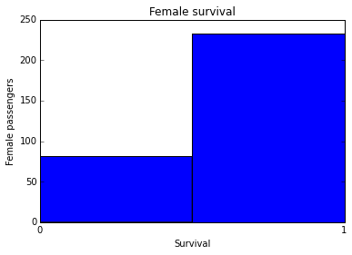

```python
#import matplotlib.pyplot as plt - only need to import once in notebook

plt.hist(female_survival, 2)  # same as before
plt.xlabel("Survival")
plt.ylabel("Female passengers")
plt.title("Female survival")
plt.xticks([0,1])  # a list of ticks

plt.show()  # ok, ready to see what it looks like
```

So out of the 314 female passengers, roughly 230 survived. Or 74% as we saw above.

## Jumping the rabbit hole

I am going to say I am happy with the plot I have. Could I clean it up further? Absolutely. I could center the ticks on the x-axis. I could change fonts on the labels, e.g., make the text larger. I could move the title up farther. I could color code the bars. There are entire books and video courses on using matplotlib plus plenty of free tutorials and advice on the web. It is safe to say that if you have a visual bent, you will have plenty of room to explore using the many features of matplotlib, i.e., go down the rabbit hole. I am going to step over the rabbit hole to get back to our exploration.

[figure not shown]

## Male survivors

My next question is how many males survived. We can copy and paste the code from female survivors and just make a few changes.

```python
male_table = [row for row in titanic_table if row['Sex'] == 'male']
male_survival = [int(row['Survived']) for row in male_table]
male_survivor_count = sum(male_survival)
male_survival_percentage = float(male_survivor_count)/len(male_table)

print(len(male_table))  # how many total male passengers
print(male_survival_percentage)  # .19 - double wow
```

```
577
0.188908145581
```

Now let's plot it.

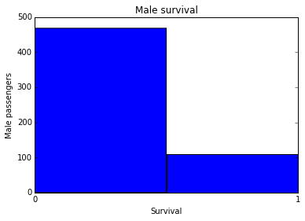

```python
#import matplotlib.pyplot as plt

plt.hist(male_survival, 2)
plt.xlabel("Survival")
plt.ylabel("Male passengers")
plt.title("Male survival")
plt.xticks([0,1])

plt.show()
```

From the plot I can see roughly 100 out of 577 males survived. Or 19% as we printed above.

## Where was everyone berthed?

Let's work with the `Pclass` column next. First we can plot how many passengers were in each cabin class. I don't need a sub-table here. Only thing I need to do is to map the string values in `Pclass` to int values.

```python
pclass = [int(row['Pclass']) for row in titanic_table]  # pull out the Pclass column and int its values
```

In general, I want to match the number of bins to the number of distinct values in the list. I have 3 distinct values in `pclass`: 1,2,3. So I ask for 3 bins. I also specify 3 ticks.

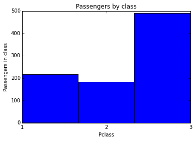

```python
plt.hist(pclass, 3)  # ask for 3 bins to match 3 classes
plt.xlabel("Pclass")
plt.ylabel("Passengers in class")
plt.title("Passengers by class")
plt.xticks([1,2,3])  # use 3 ticks to match 3 classes

plt.show()
```

## How did 3rd class passengers fare?

I can see that most of the passengers were in 3rd class. I'll build a sub-table for 3rd class passengers then check survivability. This is very similar to what we did for female passengers.

Historical note: 3rd class was at the bottom of the ship.

```
491
```

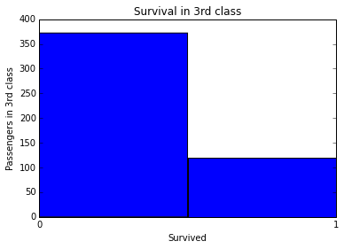

```python
class3_table = [row for row in titanic_table if row['Pclass'] == '3']
class3_survival = [int(row['Survived']) for row in class3_table]

print(len(class3_table))

plt.hist(class3_survival, 2)
plt.xlabel("Survived")
plt.ylabel("Passengers in 3rd class")
plt.title("Survival in 3rd class")
plt.xticks([0,1])

plt.show()
```

So out of the 491 passengers in 3rd class, roughly 370 perished. Not good odds if you were in 3rd class.

On the surface it might look like we are on to something with looking at 3rd class. Lots of people perished there. But lots of people perished in general. If 3rd class mirrors the general survival rate, it does not do us that much good. Let's print out the values.

```python
print(len(class3_table))  # 491
print(sum(class3_survival)/float(len(class3_table)))  # .24
```

```
491
0.242362525458
```

Reminder: the general survival rate is .38. In 3rd class it is .24. So 3rd class is lower than general. It might be worth keeping in mind when we get to building a predictor.

## Females in 3rd class

Let's do one more. I have two tables, one of females only (`female_table`), one of 3rd class only (`class3_table`). I'd like to look at the intersection of the two tables: females in 3rd class. Python does have a built-in intersection function, but we would have to introduce a new datatype, sets, to use it. I'll just use what we already know and build a new sub-table that represents the intersection. Notice I am using the `class3_table` as a starting point for the first filtered map.

```
144
```

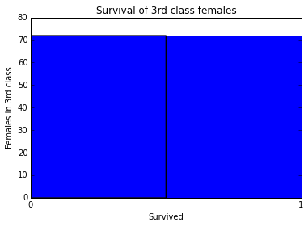

```python
fem3_table = [row for row in class3_table if row['Sex'] == 'female']
fem3_survival = [int(row['Survived']) for row in fem3_table]

print(len(fem3_table))  # 144 total females in 3rd class

plt.hist(fem3_survival, 2)
plt.xlabel("Survived")
plt.ylabel("Females in 3rd class")
plt.title("Survival of 3rd class females")
plt.xticks([0,1])

plt.show()
```

Almost 50/50 out of the 144 3rd-class female passengers. This survival rate is quite a bit lower than the overall survival rate for all female passengers (74%). Again, I'll make a mental note of this and consider it when I am building my predictor.

## One optional trick

You can turn off all the ticks on the x axis with this code:

```
plt.tick_params(axis='x', which='both', bottom='off', labelbottom='off')
```

Then you can use the xlabel to describe the 2 bars:

```
plt.xlabel('Perished - left, Survived - right')
```

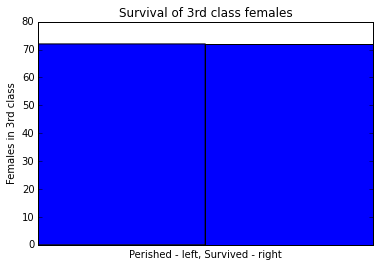

```python
plt.hist(fem3_survival, 2)

plt.xlabel('Perished - left, Survived - right')
plt.ylabel("Females in 3rd class")
plt.title("Survival of 3rd class females")
plt.xticks([0,1])
plt.tick_params(axis='x', which='both', bottom='off', labelbottom='off')

plt.show()
```

## Next up

We will continue exploring the data and add a few twists. We are getting close to building our first predictor!